# Exploration of Loan Data by Prosper

## by (Abdullah Mustafa)

## Investigation Overview

> We investigated this dataset to understand the conditions that lead to the completion of the loan. An investigation on the Borrower's APR was also conducted. The dependancy of monthly loan payment on the original loan amount was also investigated

## Dataset Overview

> This data set contains 113,937 loans with 81 variables for each loan, including loan amount, borrower rate, loan status, borrower income, and many others. To ease the analysis process, only 11 variables were chosen. The data was reduced to 101,831 after cleaning the outliers and outstanding peaks.

## LoanStatus [Completion Ratio--Categorical]

**By defining the "Loan Completion ratio" as the ratio of completed loans over the sum of the completed and incompleted loans, we can the following relation with other categorical columns:**

1. **Term**: Shorter loan terms (12) have higher completion rations than longer ones (60).
2. **IncomeRange**: Those with higher income are more likely to complete their loan payment.
3. **EmploymentStatus**: Employed persons are more capable of completing their loan than unemployed ones.
4. **IsBorrowerHomeowner**: Owning a home gives a slightly higher probablity of completing the loan.

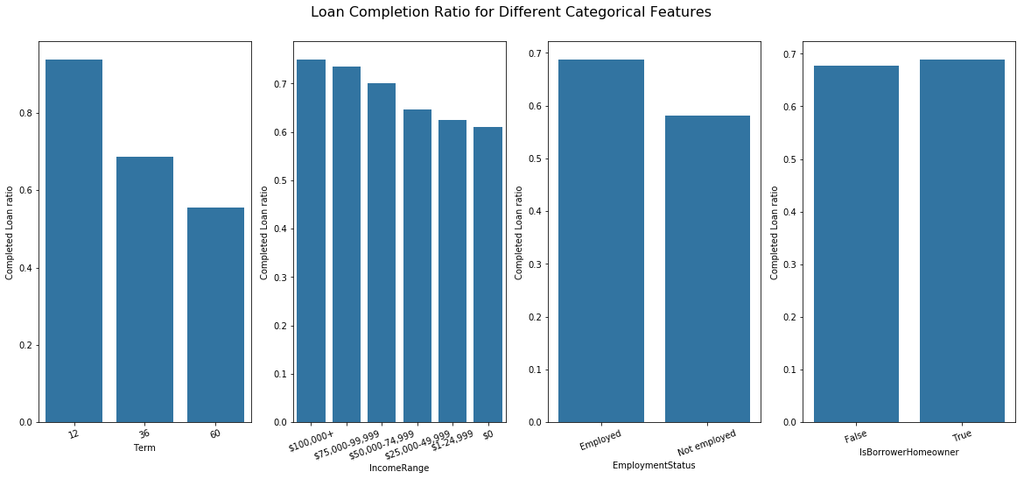

```python
fig, ax = plt.subplots(nrows = 1, ncols = 4, figsize = [20,8]);
default_color = sb.color_palette()[0]
for i,var in enumerate(['Term','IncomeRange', 'EmploymentStatus', 'IsBorrowerHomeowner']):
    Loan_status = df.groupby([var,'LoanStatus']).size()
    Loan_status = Loan_status.reset_index(name = 'loan_count')
    Loan_status_Complete = Loan_status[Loan_status.LoanStatus == "Completed"]
    Loan_status_Incomplete = Loan_status[Loan_status.LoanStatus == "Incompleted"]
    Loan_status_Complete['ratio'] = Loan_status_Complete.loan_count.values / (Loan_status_Complete.loan_count.values +
                                                              Loan_status_Incomplete.loan_count.values)
    sb.barplot(data = Loan_status_Complete, x = var,y='ratio',color=default_color,ax = ax[i])
    ax[i].set_ylabel('Completed Loan ratio')
    ax[i].set_xlabel(var)
    ax[i].set_xticklabels([t.get_text()  for t in ax[i].get_xticklabels()],rotation=20)
fig.suptitle('Loan Completion Ratio for Different Categorical Features',y=0.95,fontsize=16);
```

## LoanStatus [Completion Ratio--Numeric]

**We can also see the following relation with numeric columns:**

1. **BorrowerAPR**: Loans with lower APR are more likely to be completed.
2. **BorrowerRate**: Loans with lower interest rate are more likely to be completed.
3. **AvailableBankcardcredit**: The larger the credit, the higher the completion rate.
4. **StatedMonthlyIncome**: Overall, we can suggest that higher monthly income suggests higher completion ratios.
5. **LoanOriginalAmount**: The larger the loan, the lower the completion ratio.
6. **MonthlyLoanPayment**: Lower monthly loan payments have higher completion ratios.

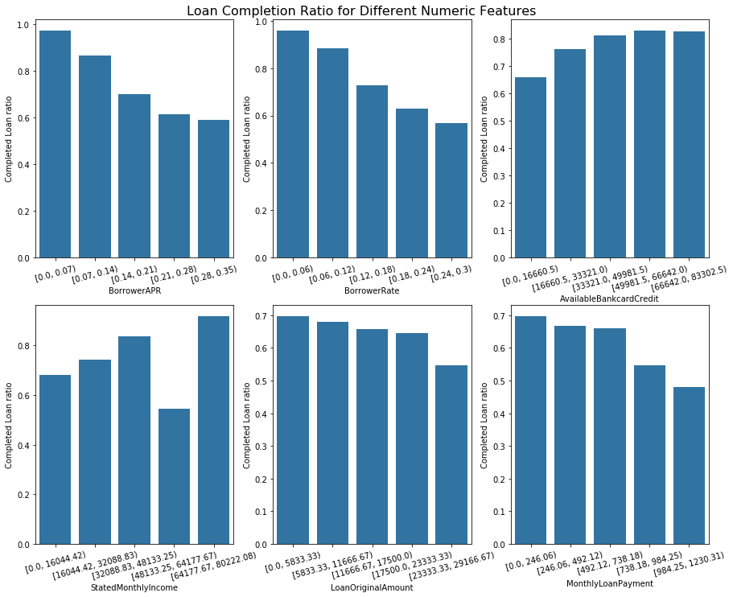

```python
fig, ax = plt.subplots(nrows = 2, ncols = 3, figsize = [15,12]);
for i,var in enumerate(num_cols):
    xbin_edges = np.arange(0, df[var].max(),df[var].max()/6).round(2)
    xbin_idxs = pd.cut(df[var], xbin_edges, right = False, include_lowest = True)
    Loan_status_count = df.groupby([xbin_idxs,'LoanStatus']).size()
    Loan_status_count = Loan_status_count.reset_index(name = 'loan_count')
    Loan_status_Complete = Loan_status_count[Loan_status_count.LoanStatus == "Completed"]
    Loan_status_Incomplete = Loan_status_count[Loan_status_count.LoanStatus == "Incompleted"]
    Loan_status_Complete['ratio'] = Loan_status_Complete.loan_count.values / (Loan_status_Complete.loan_count.values +
                                                              Loan_status_Incomplete.loan_count.values)
    sb.barplot(data = Loan_status_Complete, x = var,y='ratio',color=default_color,ax = ax[i//3,i%3])
    ax[i//3,i%3].set_ylabel('Completed Loan ratio')
    ax[i//3,i%3].set_xlabel(var)
    ax[i//3,i%3].set_xticklabels([t.get_text()  for t in ax[i//3,i%3].get_xticklabels()],rotation=15)

fig.suptitle('Loan Completion Ratio for Different Numeric Features',y=0.9,fontsize=16);
```

## BorrowerAPR [Mean change--Categorical]

**From the point plots, we can make a few conclusions concering the "BorrowerAPR":**

1. **LoanStatus**: Incompleted loans have higher APRs.
2. **Term**: Short term periods have higher APRs
3. **IncomeRange**: Higher incomes have lower APRs
4. **EmploymentStatus**: Employed status has a lower APR
5. **IsBorrowerHomeowner**: Home owners get lower APRs.

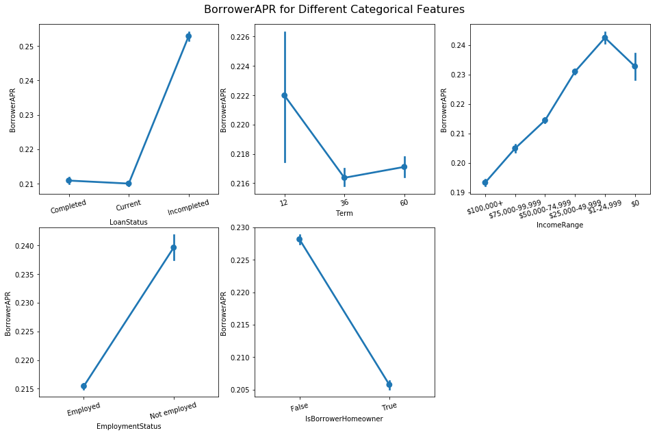

```python
fig, ax = plt.subplots(squeeze =True, figsize = [16,10]);
for i, var in enumerate(cat_cols):
    axis = plt.subplot2grid((2, 3), (i//3,i%3))
    sb.pointplot(data=df,y='BorrowerAPR',x=var,ax=axis)
    axis.set_ylabel('BorrowerAPR')
    axis.set_xlabel(var)
    axis.set_xticklabels([t.get_text()  for t in axis.get_xticklabels()],rotation=15)
fig.suptitle('BorrowerAPR for Different Categorical Features',y=0.92,fontsize=16);
```

## BorrowerAPR [Mean change--Numerical]

**The "BorrowerAPR" mean is calculated as the interaction between the numerical features, and the following conclusions could be made:**

1. **"AvaliableBankcardcredit"**: Low credit has a higher APR.
2. **"LoanOriginalAmount"**: Lower loans have higher APRs.
3. **"MonthlyLoanPayment"**: Lower payments have higher APRs.
4. **"StatedMonthlyIncome"**: The relation isn't clear.

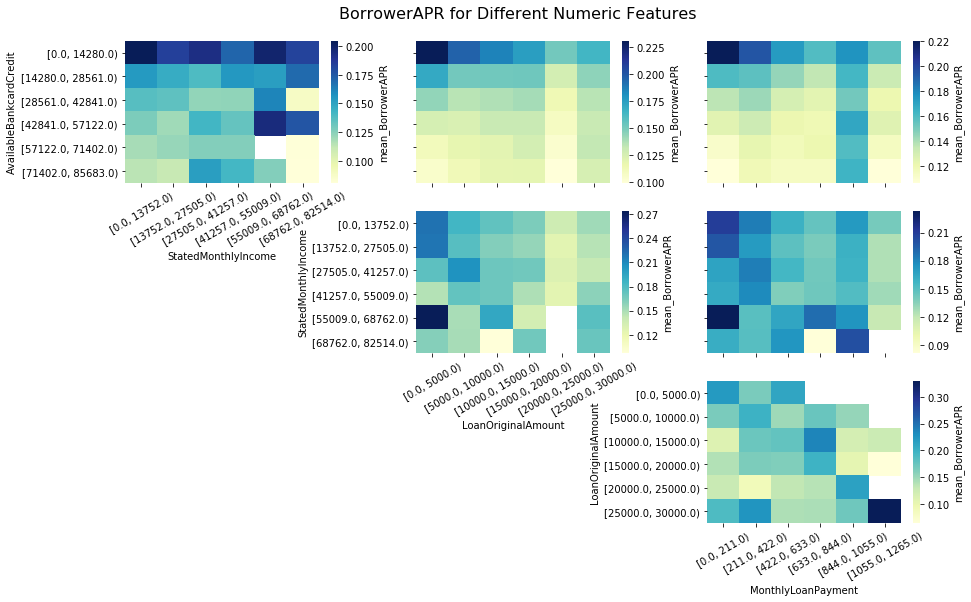

```python
cols = ['AvailableBankcardCredit', 'StatedMonthlyIncome', 'LoanOriginalAmount', 'MonthlyLoanPayment']
n = len(cols)
fig, ax = plt.subplots(figsize = [20,12],squeeze=False);
for i in range(n):
    for j in range(i+1,n):
        axis = plt.subplot2grid((n, n), (i, j))
        heatmapGrid_num(cols[i], cols[j],axis)
        if j != i + 1:
            axis.set_ylabel('')
            axis.set_yticklabels([])
            axis.set_xlabel('')
            axis.set_xticklabels([])
fig.suptitle('BorrowerAPR for Different Numeric Features',x = 0.6, y=0.92,fontsize=16);
```

## Loan amount Vs. Monthly payment

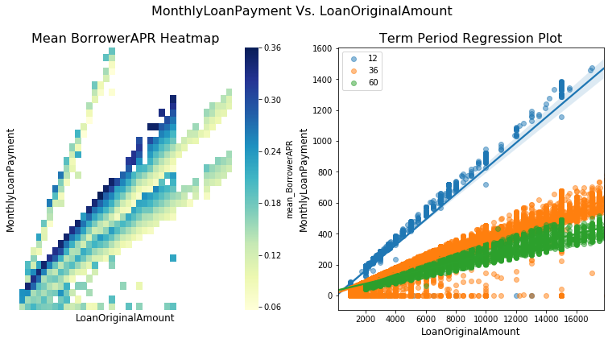

```python
fig, ax = plt.subplots(nrows = 1, ncols = 2, figsize = [13,6]);
#Heatmap with mean BorrowerAPR
sb.heatmap(mean_APR,cmap = "YlGnBu",xticklabels=False,yticklabels=False, cbar_kws = {'label' : 'mean_BorrowerAPR'},ax=ax[0]);
ax[0].set_title('Mean BorrowerAPR Heatmap',fontsize = 16);
ax[0].set_ylabel('MonthlyLoanPayment',fontsize = 12);
ax[0].set_xlabel('LoanOriginalAmount',fontsize = 12);
plt.sca(ax[0]);
plt.gca().invert_yaxis();
#Regression plot for different Term periods
g = sb.FacetGrid(data=df,hue='Term',sharey=True);
g.map(sb.regplot,'LoanOriginalAmount','MonthlyLoanPayment',scatter_kws={'alpha':0.5},ax=ax[1]);
g.fig.delaxes(g.axes[0][0]);
ax[1].set_title('Term Period Regression Plot',fontsize = 16);
ax[1].set_ylabel('MonthlyLoanPayment',fontsize = 12);
ax[1].set_xlabel('LoanOriginalAmount',fontsize = 12);
ax[1].legend();
fig.suptitle('MonthlyLoanPayment Vs. LoanOriginalAmount',y=1,fontsize=16);
```

## Rich gets richer!!

> **With higher income, one can afford to get larger loans at low APRs. Sounds unfair to the poor!** **Also, long term periods allow for larger loan amounts.**

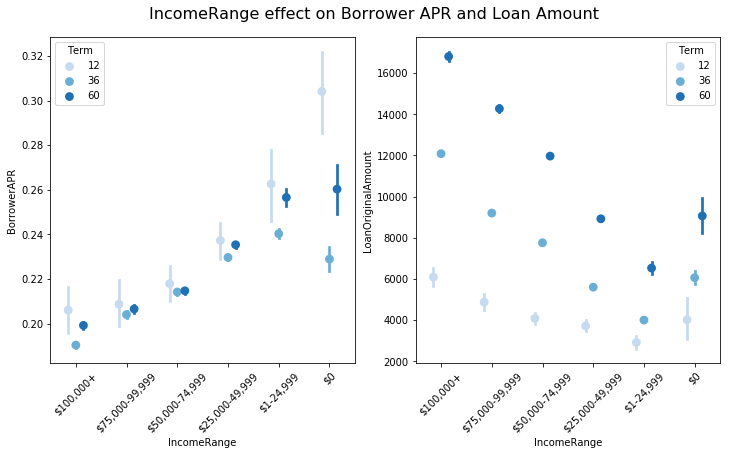

```python
#HCrate point plots to show the significant of Income on loan amount and APR.
fig, ax = plt.subplots(ncols = 2, figsize = [12,6]);
g1 = sb.pointplot(data=df,y='BorrowerAPR',x='IncomeRange',hue='Term',dodge=0.3,linestyles='',palette='Blues',ax=ax[0]);
ax[0].set_xticklabels([textwrap.fill(t.get_text(), 15)  for t in ax[0].get_xticklabels()],rotation=45);
sb.pointplot(data=df,y='LoanOriginalAmount',x='IncomeRange',hue='Term',dodge=0.3,linestyles='',palette='Blues',ax=ax[1]);
ax[1].set_xticklabels([textwrap.fill(t.get_text(), 15)  for t in ax[1].get_xticklabels()],rotation=45);
fig.suptitle('IncomeRange effect on Borrower APR and Loan Amount',y=0.95,fontsize=16);
```